# Biostat 203B Homework 2

Due Feb 6 @ 11:59PM

Seamus Gallivan

```r
knitr::opts_chunk$set(echo = TRUE, cache = TRUE, cache.lazy = FALSE)
library(tidyverse)
library(data.table)
library(lubridate)
```

```r
os <- sessionInfo()$running
if (str_detect(os, "Linux")) {
  mimic_path <- "/mnt/mimiciv/1.0"
} else if (str_detect(os, "macOS")) {
  mimic_path <- "/Users/huazhou/Documents/Box Sync/MIMIC/mimic-iv-1.0"
}
```

In this exercise, we use tidyverse (ggpot2, dplyr, etc) to explore the [MIMIC-IV](https://mimic.mit.edu/docs/iv/) data introduced in [homework 1](https://ucla-biostat-203b.github.io/2022winter/hw/hw1/hw1.html) and to build a cohort of ICU stays.

```r
# tree -s -L 2 /Users/huazhou/Documents/Box\ Sync/MIMIC/mimic-iv-1.0
system(str_c("tree -s -L 2 ", shQuote(mimic_path)), intern = TRUE)
```

```
##  [1] "/mnt/mimiciv/1.0"
##  [2] "├── [       4096]  core"
##  [3] "│   ├── [   17208966]  admissions.csv.gz"
##  [4] "│   ├── [        606]  index.html"
##  [5] "│   ├── [    2955582]  patients.csv.gz"
##  [6] "│   └── [   53014503]  transfers.csv.gz"
##  [7] "├── [       4096]  hosp"
##  [8] "│   ├── [     430049]  d_hcpcs.csv.gz"
##  [9] "│   ├── [   29531152]  diagnoses_icd.csv.gz"
## [10] "│   ├── [     863239]  d_icd_diagnoses.csv.gz"
## [11] "│   ├── [     579998]  d_icd_procedures.csv.gz"
## [12] "│   ├── [      14898]  d_labitems.csv.gz"
## [13] "│   ├── [   11684062]  drgcodes.csv.gz"
## [14] "│   ├── [  515763427]  emar.csv.gz"
## [15] "│   ├── [  476252563]  emar_detail.csv.gz"
```

[output cut: 24 more lines]

## Q1. `read.csv` (base R) vs `read_csv` (tidyverse) vs `fread` (data.table)

There are quite a few utilities in R for reading plain text data files. Let us test the speed of reading a moderate sized compressed csv file, `admissions.csv.gz`, by three programs: `read.csv` in base R, `read_csv` in tidyverse, and `fread` in the popular data.table package.

Which function is fastest? Is there difference in the (default) parsed data types? (Hint: R function `system.time` measures run times.)

For later questions, we stick to the tidyverse.

**Solution**

```r
system.time(read.csv("/mnt/mimiciv/1.0/core/admissions.csv.gz"))
```

```
##    user  system elapsed
##  42.202   0.254  42.466
```

```r
system.time(read_csv("/mnt/mimiciv/1.0/core/admissions.csv.gz"))
```

```
##    user  system elapsed
##   3.525   0.274   2.197
```

```r
system.time(fread("/mnt/mimiciv/1.0/core/admissions.csv.gz"))
```

```
##    user  system elapsed
##   1.457   0.086   0.889
```

## Q2. ICU stays

`icustays.csv.gz` (https://mimic.mit.edu/docs/iv/modules/icu/icustays/) contains data about Intensive Care Units (ICU) stays. The first 10 lines are

```r
system(
  str_c(
    "zcat < ",
    shQuote(str_c(mimic_path, "/icu/icustays.csv.gz")),
    " | head"
    ),
  intern = TRUE
)
```

```
##  [1] "subject_id,hadm_id,stay_id,first_careunit,last_careunit,intime,outtime,los"
##  [2] "17867402,24528534,31793211,Trauma SICU (TSICU),Trauma SICU (TSICU),2154-03-03 04:11:00,2154-03-04 18:16:56,1.5874537037037035"
##  [3] "14435996,28960964,31983544,Trauma SICU (TSICU),Trauma SICU (TSICU),2150-06-19 17:57:00,2150-06-22 18:33:54,3.025625"
##  [4] "17609946,27385897,33183475,Trauma SICU (TSICU),Trauma SICU (TSICU),2138-02-05 18:54:00,2138-02-15 12:42:05,9.741724537037038"
##  [5] "18966770,23483021,34131444,Trauma SICU (TSICU),Trauma SICU (TSICU),2123-10-25 10:35:00,2123-10-25 18:59:47,0.35054398148148147"
##  [6] "12776735,20817525,34547665,Neuro Stepdown,Neuro Stepdown,2200-07-12 00:33:00,2200-07-13 16:44:40,1.6747685185185184"
##  [7] "10215159,24283593,34569476,Trauma SICU (TSICU),Trauma SICU (TSICU),2124-09-20 15:05:29,2124-09-21 22:06:58,1.2926967592592593"
##  [8] "14489052,26516390,35056286,Trauma SICU (TSICU),Trauma SICU (TSICU),2118-10-26 10:33:56,2118-10-26 20:28:10,0.4126620370370371"
##  [9] "15914763,28906020,36909804,Trauma SICU (TSICU),Trauma SICU (TSICU),2176-12-14 12:00:00,2176-12-17 11:47:01,2.9909837962962964"
## [10] "16256226,20013290,39289362,Neuro Stepdown,Neuro Stepdown,2150-12-20 16:09:08,2150-12-21 14:58:40,0.9510648148148149"
```

1. Import `icustatys.csv.gz` as a tibble `icustays_tble`.

**Solution**

```r
icustays_tble1 <- read_csv("/mnt/mimiciv/1.0/icu/icustays.csv.gz")
```

2. How many unique `subject_id`? Can a `subject_id` have multiple ICU stays?

**Solution**

53,150 unique ‘subject_id’. Yes, from quick glimpse at the tibble below, subject_id number 10002428 has 4 ICU stays.

```r
count(icustays_tble1, subject_id)
```

```
## # A tibble: 53,150 × 2
##    subject_id     n
##         <dbl> <int>
##  1   10000032     1
##  2   10000980     1
##  3   10001217     2
##  4   10001725     1
##  5   10001884     1
##  6   10002013     1
##  7   10002155     3
##  8   10002223     1
##  9   10002348     1
## 10   10002428     4
## # … with 53,140 more rows
```

3. For each `subject_id`, let’s only keep the first ICU stay in the tibble `icustays_tble`.

**Solution**

```r
icustays_tble <- icustays_tble1 %>%
  arrange(intime) %>%
  distinct(subject_id, .keep_all = TRUE)
icustays_tble
```

```
## # A tibble: 53,150 × 8
##    subject_id  hadm_id  stay_id first_careunit last_careunit intime
##         <dbl>    <dbl>    <dbl> <chr>          <chr>         <dttm>
##  1   18106347 24305596 30588857 Cardiac Vascu… Cardiac Vasc… 2110-01-11 10:16:06
##  2   17195991 23542772 38319097 Surgical Inte… Surgical Int… 2110-01-12 00:54:00
##  3   16284044 23864737 36817845 Cardiac Vascu… Cardiac Vasc… 2110-01-13 09:09:40
##  4   18122666 23883987 39753527 Medical/Surgi… Medical/Surg… 2110-01-14 07:22:00
##  5   18780420 28977824 32140208 Neuro Surgica… Neuro Surgic… 2110-01-17 00:28:00
##  6   15092543 28768907 38339174 Neuro Interme… Neuro Interm… 2110-01-17 22:49:13
##  7   13201095 28453791 39953418 Coronary Care… Coronary Car… 2110-01-18 14:46:27
##  8   12770182 20446666 34901199 Medical Inten… Medical Inte… 2110-01-18 17:47:47
##  9   12224263 23294937 37546608 Trauma SICU (… Trauma SICU … 2110-01-20 14:01:00
## 10   19564586 22461053 37310703 Coronary Care… Coronary Car… 2110-01-20 21:06:30
## # … with 53,140 more rows, and 2 more variables: outtime <dttm>, los <dbl>
```

## Q3. `admission` data

Information of the patients admitted into hospital is available in `admissions.csv.gz`. See https://mimic.mit.edu/docs/iv/modules/core/admissions/ for details of each field in this file. The first 10 lines are

```r
system(
  str_c(
    "zcat < ",
    shQuote(str_c(mimic_path, "/core/admissions.csv.gz")),
    " | head"
    ),
  intern = TRUE
)
```

```
##  [1] "subject_id,hadm_id,admittime,dischtime,deathtime,admission_type,admission_location,discharge_location,insurance,language,marital_status,ethnicity,edregtime,edouttime,hospital_expire_flag"
##  [2] "14679932,21038362,2139-09-26 14:16:00,2139-09-28 11:30:00,,ELECTIVE,,HOME,Other,ENGLISH,SINGLE,UNKNOWN,,,0"
##  [3] "15585972,24941086,2123-10-07 23:56:00,2123-10-12 11:22:00,,ELECTIVE,,HOME,Other,ENGLISH,,WHITE,,,0"
##  [4] "11989120,21965160,2147-01-14 09:00:00,2147-01-17 14:25:00,,ELECTIVE,,HOME,Other,ENGLISH,,UNKNOWN,,,0"
##  [5] "17817079,24709883,2165-12-27 17:33:00,2165-12-31 21:18:00,,ELECTIVE,,HOME,Other,ENGLISH,,OTHER,,,0"
##  [6] "15078341,23272159,2122-08-28 08:48:00,2122-08-30 12:32:00,,ELECTIVE,,HOME,Other,ENGLISH,,BLACK/AFRICAN AMERICAN,,,0"
##  [7] "19124609,20517215,2169-03-14 12:44:00,2169-03-20 19:15:00,,ELECTIVE,,HOME,Other,ENGLISH,,UNKNOWN,,,0"
##  [8] "17301855,29732723,2140-06-06 14:23:00,2140-06-08 14:25:00,,ELECTIVE,,HOME,Other,ENGLISH,,WHITE,,,0"
##  [9] "17991012,24298836,2181-07-10 20:28:00,2181-07-12 15:49:00,,ELECTIVE,,HOME,Other,ENGLISH,,WHITE,,,0"
## [10] "16865435,23216961,2185-07-19 02:12:00,2185-07-21 11:50:00,,ELECTIVE,,HOME,Other,ENGLISH,,WHITE,,,0"
```

1. Import `admissions.csv.gz` as a tibble `admissions_tble`.

**Solution**

```r
admissions_tble1 <- read_csv("/mnt/mimiciv/1.0/core/admissions.csv.gz")
```

2. Let’s only keep the admissions that have a match in `icustays_tble` according to `subject_id` and `hadm_id`.

```r
admissions_tble <- semi_join(admissions_tble1, icustays_tble,
                              by = c("subject_id", "hadm_id"))
admissions_tble %>% arrange(subject_id)
```

```
## # A tibble: 53,150 × 15
##    subject_id  hadm_id admittime           dischtime
##         <dbl>    <dbl> <dttm>              <dttm>
##  1   10000032 29079034 2180-07-23 12:35:00 2180-07-25 17:55:00
##  2   10000980 26913865 2189-06-27 07:38:00 2189-07-03 03:00:00
##  3   10001217 24597018 2157-11-18 22:56:00 2157-11-25 18:00:00
##  4   10001725 25563031 2110-04-11 15:08:00 2110-04-14 15:00:00
##  5   10001884 26184834 2131-01-07 20:39:00 2131-01-20 05:15:00
##  6   10002013 23581541 2160-05-18 07:45:00 2160-05-23 13:30:00
##  7   10002155 23822395 2129-08-04 12:44:00 2129-08-18 16:53:00
##  8   10002223 22494570 2158-01-15 08:00:00 2158-01-20 19:29:00
##  9   10002348 22725460 2112-11-30 22:22:00 2112-12-10 17:56:00
## 10   10002428 28662225 2156-04-12 14:16:00 2156-04-29 16:26:00
## # … with 53,140 more rows, and 11 more variables: deathtime <dttm>,
## #   admission_type <chr>, admission_location <chr>, discharge_location <chr>,
## #   insurance <chr>, language <chr>, marital_status <chr>, ethnicity <chr>,
## #   edregtime <dttm>, edouttime <dttm>, hospital_expire_flag <dbl>
```

3. Summarize the following variables by graphics.
- admission year
- admission month
- admission month day
- admission week day
- admission hour (anything unusual?)

**Solution**

Admission month, monthday and weekly are all uniformly distributed. Interestingly enough, admission hour peaks at midnight, decreases until it spikes at 7am, jumps back down at 8am and gradually increases until 3pm where it stays constant until midnight.

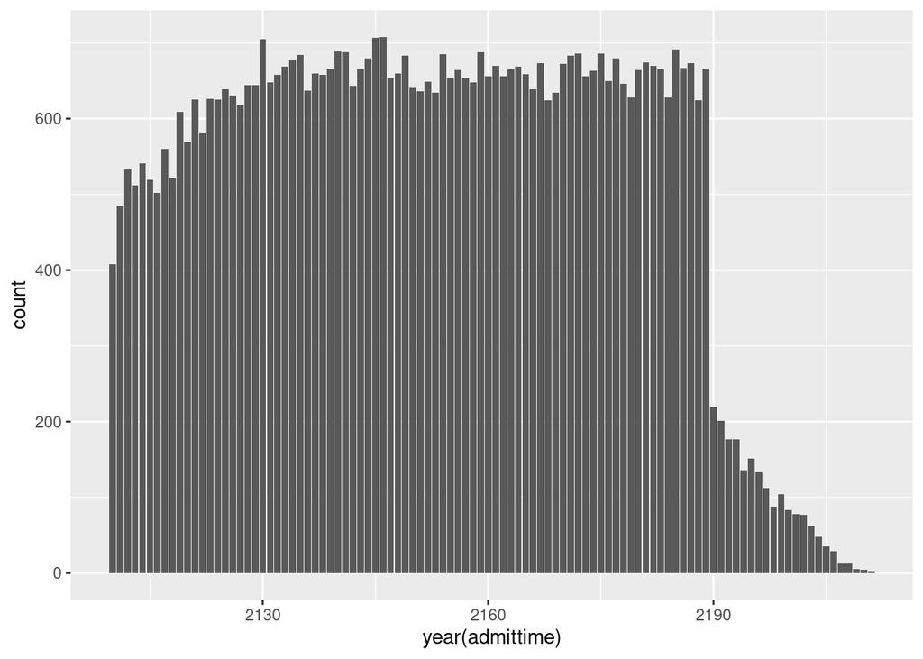

```r
#admission year
c <- ggplot(admissions_tble, aes(year(admittime)))
c + geom_bar()
```

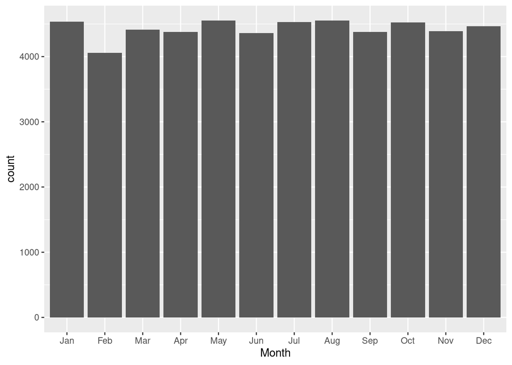

```r
#admission month
d <- ggplot(admissions_tble, aes(lubridate::month(admittime, label = T)))
d + geom_bar() + labs(x = "Month")
```

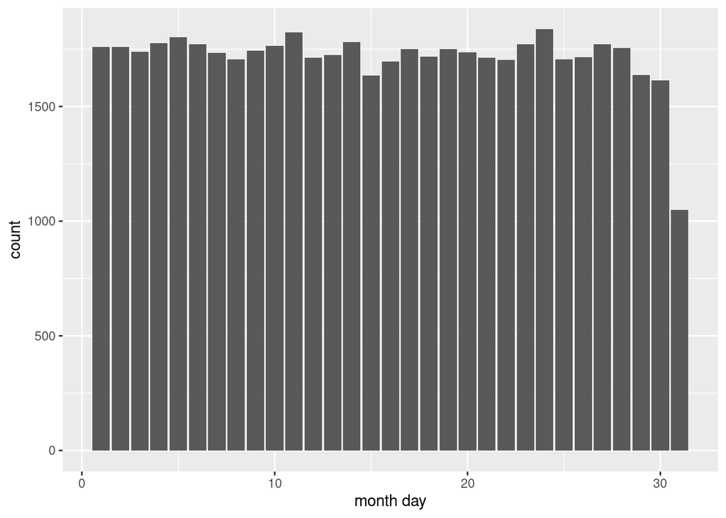

```r
#admission month day
a <- ggplot(admissions_tble, aes(lubridate::mday(admittime)))
a + geom_bar() + labs(x = "month day")
```

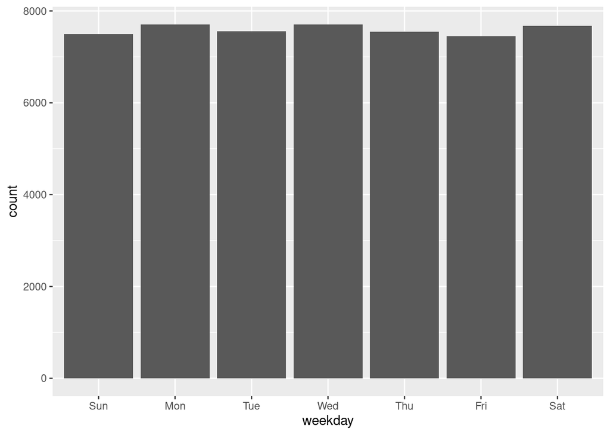

```r
#admission week day
b <- ggplot(admissions_tble, aes(lubridate::wday(admittime, label = T)))
b + geom_bar() + labs(x = "weekday")
```

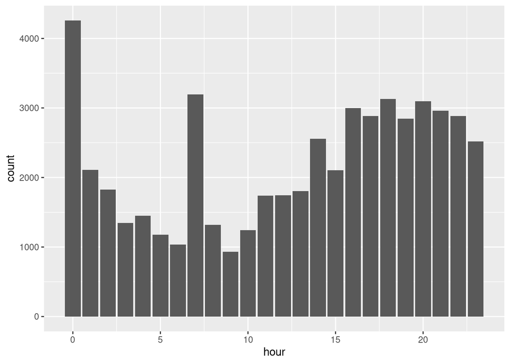

```r
#admission hour
e <- ggplot(admissions_tble, aes(lubridate::hour(admittime)))
e + geom_bar() + labs(x = "hour")
```

## Q4. `patients` data

Patient information is available in `patients.csv.gz`. See https://mimic.mit.edu/docs/iv/modules/core/patients/ for details of each field in this file. The first 10 lines are

```r
system(
  str_c(
    "zcat < ",
    shQuote(str_c(mimic_path, "/core/patients.csv.gz")),
    " | head"
    ),
  intern = TRUE
)
```

```
##  [1] "subject_id,gender,anchor_age,anchor_year,anchor_year_group,dod"
##  [2] "10000048,F,23,2126,2008 - 2010,"
##  [3] "10002723,F,0,2128,2017 - 2019,"
##  [4] "10003939,M,0,2184,2008 - 2010,"
##  [5] "10004222,M,0,2161,2014 - 2016,"
##  [6] "10005325,F,0,2154,2011 - 2013,"
##  [7] "10007338,F,0,2153,2017 - 2019,"
##  [8] "10008101,M,0,2142,2008 - 2010,"
##  [9] "10009872,F,0,2168,2014 - 2016,"
## [10] "10011333,F,0,2132,2014 - 2016,"
```

1. Import `patients.csv.gz` (https://mimic.mit.edu/docs/iv/modules/core/patients/) as a tibble `patients_tble` and only keep the patients who have a match in `icustays_tble` (according to `subject_id`).

**Solution**

```r
patients_tble1 <- read_csv("/mnt/mimiciv/1.0/core/patients.csv.gz")
patients_tble <- semi_join(patients_tble1, icustays_tble, by = "subject_id")
patients_tble %>% arrange(subject_id)
```

```
## # A tibble: 53,150 × 6
##    subject_id gender anchor_age anchor_year anchor_year_group dod
##         <dbl> <chr>       <dbl>       <dbl> <chr>             <date>
##  1   10000032 F              52        2180 2014 - 2016       NA
##  2   10000980 F              73        2186 2008 - 2010       NA
##  3   10001217 F              55        2157 2011 - 2013       NA
##  4   10001725 F              46        2110 2011 - 2013       NA
##  5   10001884 F              68        2122 2008 - 2010       2131-01-20
##  6   10002013 F              53        2156 2008 - 2010       NA
##  7   10002155 F              80        2128 2008 - 2010       2131-03-10
##  8   10002223 M              21        2158 2008 - 2010       NA
##  9   10002348 F              77        2112 2017 - 2019       NA
## 10   10002428 F              80        2155 2011 - 2013       NA
## # … with 53,140 more rows
```

2. Summarize variables `gender` and `anchor_age`, and explain any patterns you see.

**Solution**

The majority of the anchor_age distribution lies between 60 and 80 years of age. Gender is male dominant.

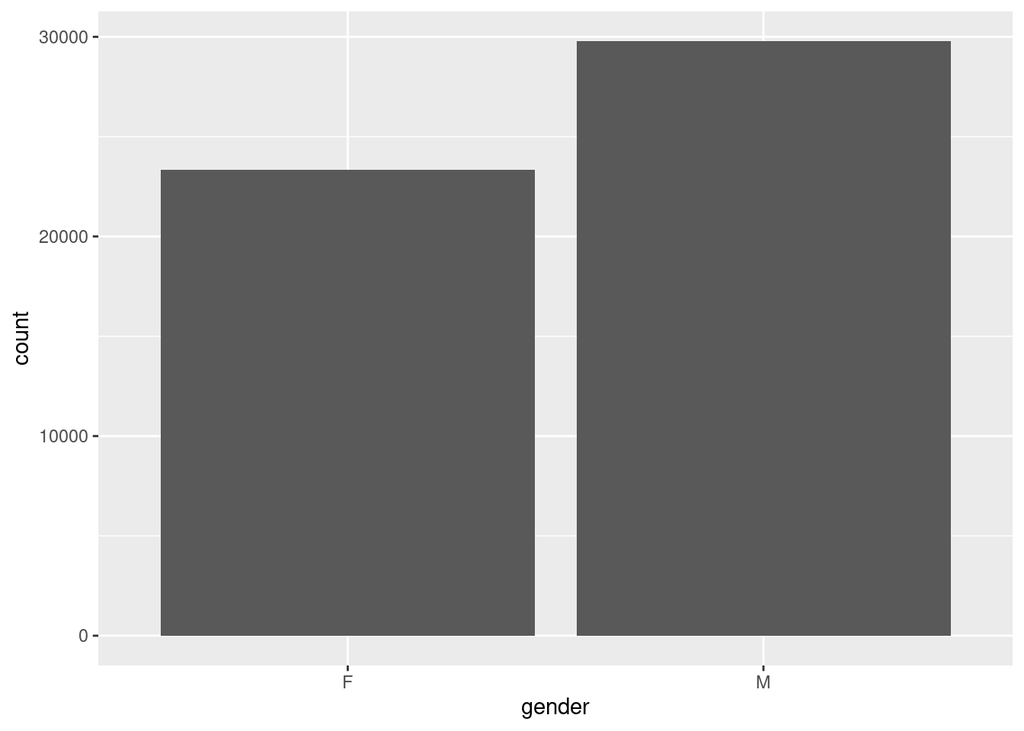

```r
#summarize gender
gender <- ggplot(patients_tble, aes(gender))
gender + geom_bar()
```

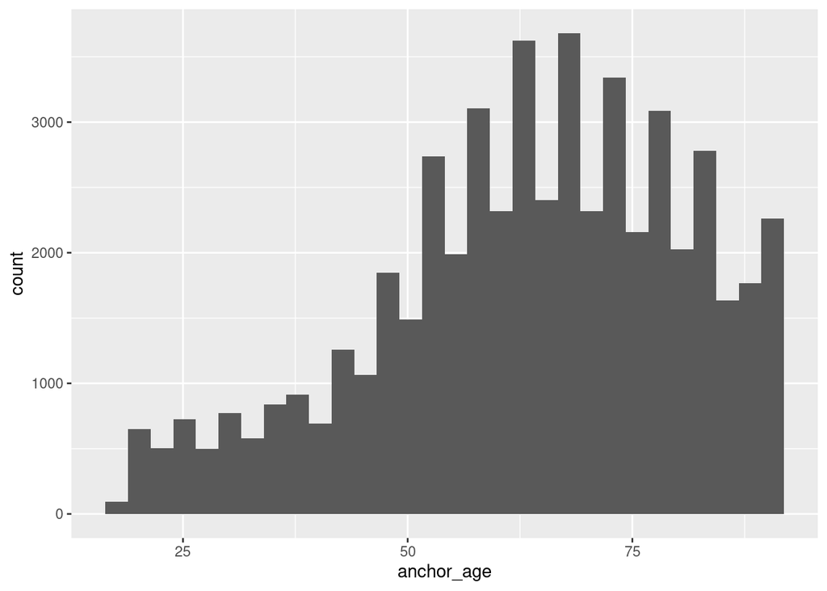

```r
#summarize anchor_age
age <- ggplot(patients_tble, aes(anchor_age))
age + geom_histogram()
```

## Q5. Lab results

`labevents.csv.gz` (https://mimic.mit.edu/docs/iv/modules/hosp/labevents/) contains all laboratory measurements for patients. The first 10 lines are

```r
system(
  str_c(
    "zcat < ",
    shQuote(str_c(mimic_path, "/hosp/labevents.csv.gz")),
    " | head"
    ),
  intern = TRUE
)
```

```
##  [1] "labevent_id,subject_id,hadm_id,specimen_id,itemid,charttime,storetime,value,valuenum,valueuom,ref_range_lower,ref_range_upper,flag,priority,comments"
##  [2] "670,10000048,,6448755,51484,2126-11-22 19:20:00,2126-11-22 20:07:00,150,150,mg/dL,,,,STAT,"
##  [3] "673,10000048,,6448755,51491,2126-11-22 19:20:00,2126-11-22 20:07:00,6.5,6.5,units,5,8,,STAT,"
##  [4] "675,10000048,,6448755,51498,2126-11-22 19:20:00,2126-11-22 20:07:00,1.029,1.029, ,1.001,1.035,,STAT,"
##  [5] "683,10000048,,82729055,50861,2126-11-22 20:45:00,2126-11-23 00:55:00,39,39,IU/L,0,40,,STAT,"
##  [6] "684,10000048,,82729055,50862,2126-11-22 20:45:00,2126-11-23 00:55:00,4.7,4.7,g/dL,3.4,4.8,,STAT,"
##  [7] "685,10000048,,82729055,50863,2126-11-22 20:45:00,2126-11-23 00:55:00,45,45,IU/L,39,117,,STAT,"
##  [8] "686,10000048,,82729055,50868,2126-11-22 20:45:00,2126-11-22 21:32:00,13,13,mEq/L,8,20,,STAT,"
##  [9] "687,10000048,,82729055,50878,2126-11-22 20:45:00,2126-11-23 00:55:00,28,28,IU/L,0,40,,STAT,"
## [10] "688,10000048,,82729055,50882,2126-11-22 20:45:00,2126-11-22 21:32:00,26,26,mEq/L,22,32,,STAT,"
```

`d_labitems.csv.gz` is the dictionary of lab measurements.

```r
system(
  str_c(
    "zcat < ",
    shQuote(str_c(mimic_path, "/hosp/d_labitems.csv.gz")),
    " | head"
    ),
  intern = TRUE
)
```

```
##  [1] "itemid,label,fluid,category,loinc_code"
##  [2] "51905, ,Other Body Fluid,Chemistry,"
##  [3] "51532,11-Deoxycorticosterone,Blood,Chemistry,"
##  [4] "51957,17-Hydroxycorticosteroids,Urine,Chemistry,"
##  [5] "51958,\"17-Ketosteroids, Urine\",Urine,Chemistry,"
##  [6] "52068,24 Hr,Blood,Hematology,"
##  [7] "51066,24 hr Calcium,Urine,Chemistry,"
##  [8] "51067,24 hr Creatinine,Urine,Chemistry,"
##  [9] "51068,24 hr Protein,Urine,Chemistry,"
## [10] "50853,25-OH Vitamin D,Blood,Chemistry,"
```

1. Find how many rows are in `labevents.csv.gz`.

**Solution**

```r
system(
  str_c(
    "zcat < ",
    shQuote(str_c(mimic_path, "/hosp/d_labitems.csv.gz")),
    " | tail -n +2 | wc -l"
    ),
  intern = TRUE
)
```

```
## [1] "1630"
```

2. We are interested in the lab measurements of creatinine (50912), potassium (50971), sodium (50983), chloride (50902), bicarbonate (50882), hematocrit (51221), white blood cell count (51301), glucose (50931), magnesium (50960), and calcium (50893). Retrieve a subset of `labevents.csv.gz` only containing these items for the patients in `icustays_tble` as a tibble `labevents_tble`.

   Hint: `labevents.csv.gz` is a data file too big to be read in by the `read_csv` function in its default setting. Utilize the `col_select` and `lazy` options in the `read_csv` function to reduce the memory burden.

**Solution**

```r
labevents_tble1 <-
  read_csv(str_c(mimic_path, "/hosp/labevents_filtered_itemid.csv.gz"),
      col_select = c(subject_id, itemid, charttime, valuenum),
      col_types = cols_only(subject_id = col_double(),
                            itemid = col_double(),
                            charttime = col_datetime(),
                            valuenum = col_double()),
      lazy = TRUE) %>%
  semi_join(icustays_tble, by = c("subject_id"))
```

```r
d_labitems <- read_csv(str_c(mimic_path, "/hosp/d_labitems.csv.gz"))
labevents_tble1 <- left_join(labevents_tble1, d_labitems, by = "itemid")
```

3. Further restrict `labevents_tble` to the first lab measurement during the ICU stay.

```r
labevents_tble <- labevents_tble1 %>%
  # pull in intime from icu stay
  left_join(select(icustays_tble, subject_id, intime), by = "subject_id") %>%
  #only lab measures after intime
  filter(charttime >= intime) %>%
  #first lab measurement after intime for each subjectid x itemid combo
  group_by(subject_id, itemid) %>%
  arrange(charttime, .by_group = TRUE) %>%
  slice_head(n = 1) %>%
  ungroup() %>%
  select(subject_id, label, valuenum) %>%
  pivot_wider(names_from = label, values_from = valuenum)
labevents_tble
```

```
## # A tibble: 52,544 × 11
##    subject_id Bicarbonate `Calcium, Total` Chloride Creatinine Glucose Magnesium
##         <dbl>       <dbl>            <dbl>    <dbl>      <dbl>   <dbl>     <dbl>
##  1   10000032          21              9.3      102        0.5     115       2.3
##  2   10000980          23              9.2      103        2.2     144       2
##  3   10001217          23              8.2      104        0.4     113       1.9
##  4   10001725          24              9.1      106        0.8     146       1.5
##  5   10001884          33              9.8       96        1.1     148       2.2
##  6   10002013          23              8.2      109        1.1      98       2.1
##  7   10002155          25              8.8      106        0.9      95       2
##  8   10002223          26              8.7      102        0.8      88       2
##  9   10002348          23              9.4      107        0.8     127       1.6
## 10   10002428          20              7.4       98        0.8      99       1.4
## # … with 52,534 more rows, and 4 more variables: Potassium <dbl>, Sodium <dbl>,
## #   Hematocrit <dbl>, White Blood Cells <dbl>
```

4. Summarize the lab measurements by appropriate numerics and graphics.

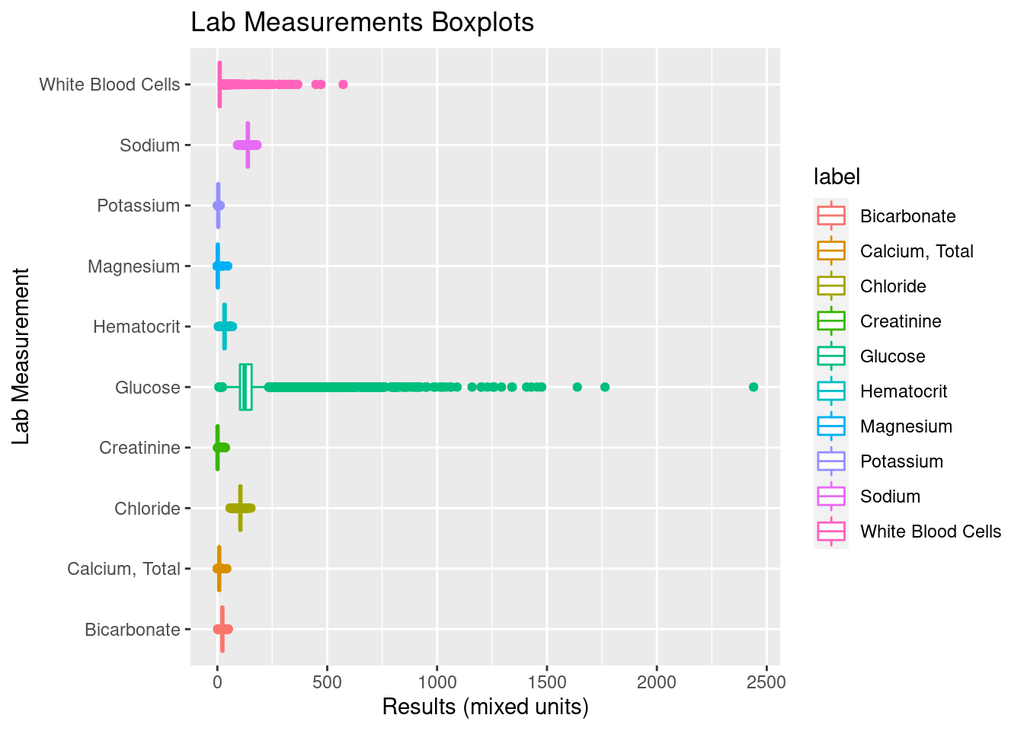

```r
lab_box <- labevents_tble %>%
  select(2:11) %>%
  pivot_longer(1:10, names_to = "label", values_to = "values")

fivefour <- ggplot(lab_box, aes(x = label, y = values, color = label)) +
  geom_boxplot()
fivefour + coord_flip() + xlab("Lab Measurement") +
  ylab("Results (mixed units)") + ggtitle("Lab Measurements Boxplots")
```

## Q6. Vitals from charted events

`chartevents.csv.gz` (https://mimic.mit.edu/docs/iv/modules/icu/chartevents/) contains all the charted data available for a patient. During their ICU stay, the primary repository of a patient’s information is their electronic chart. The `itemid` variable indicates a single measurement type in the database. The `value` variable is the value measured for `itemid`. The first 10 lines of `chartevents.csv.gz` are

```r
system(
  str_c(
    "zcat < ",
    shQuote(str_c(mimic_path, "/icu/chartevents.csv.gz")),
    " | head"),
  intern = TRUE
)
```

```
##  [1] "subject_id,hadm_id,stay_id,charttime,storetime,itemid,value,valuenum,valueuom,warning"
##  [2] "10003700,28623837,30600691,2165-04-24 05:10:00,2165-04-24 05:11:00,228236,0,0,,0"
##  [3] "10003700,28623837,30600691,2165-04-24 05:12:00,2165-04-24 05:14:00,225067,0,0,,0"
##  [4] "10003700,28623837,30600691,2165-04-24 05:12:00,2165-04-24 05:14:00,225070,1,1,,0"
##  [5] "10003700,28623837,30600691,2165-04-24 05:12:00,2165-04-24 05:14:00,225076,1,1,,0"
##  [6] "10003700,28623837,30600691,2165-04-24 05:12:00,2165-04-24 05:14:00,225078,1,1,,0"
##  [7] "10003700,28623837,30600691,2165-04-24 05:12:00,2165-04-24 05:14:00,225086,1,1,,0"
##  [8] "10003700,28623837,30600691,2165-04-24 05:12:00,2165-04-24 05:14:00,225091,1,1,,0"
##  [9] "10003700,28623837,30600691,2165-04-24 05:12:00,2165-04-24 05:14:00,225103,1,1,,0"
## [10] "10003700,28623837,30600691,2165-04-24 05:12:00,2165-04-24 05:14:00,225106,1,1,,0"
```

`d_items.csv.gz` (https://mimic.mit.edu/docs/iv/modules/icu/d_items/) is the dictionary for the `itemid` in `chartevents.csv.gz`.

```r
system(
  str_c(
    "zcat < ",
    shQuote(str_c(mimic_path, "/icu/d_items.csv.gz")),
    " | head"),
  intern = TRUE
)
```

```
##  [1] "itemid,label,abbreviation,linksto,category,unitname,param_type,lownormalvalue,highnormalvalue"
##  [2] "220003,ICU Admission date,ICU Admission date,datetimeevents,ADT,,Date and time,,"
##  [3] "220045,Heart Rate,HR,chartevents,Routine Vital Signs,bpm,Numeric,,"
##  [4] "220046,Heart rate Alarm - High,HR Alarm - High,chartevents,Alarms,bpm,Numeric,,"
##  [5] "220047,Heart Rate Alarm - Low,HR Alarm - Low,chartevents,Alarms,bpm,Numeric,,"
##  [6] "220048,Heart Rhythm,Heart Rhythm,chartevents,Routine Vital Signs,,Text,,"
##  [7] "220050,Arterial Blood Pressure systolic,ABPs,chartevents,Routine Vital Signs,mmHg,Numeric,90,140"
##  [8] "220051,Arterial Blood Pressure diastolic,ABPd,chartevents,Routine Vital Signs,mmHg,Numeric,60,90"
##  [9] "220052,Arterial Blood Pressure mean,ABPm,chartevents,Routine Vital Signs,mmHg,Numeric,,"
## [10] "220056,Arterial Blood Pressure Alarm - Low,ABP Alarm - Low,chartevents,Alarms,mmHg,Numeric,,"
```

1. We are interested in the vitals for ICU patients: heart rate (220045), mean non-invasive blood pressure (220181), systolic non-invasive blood pressure (220179), body temperature in Fahrenheit (223761), and respiratory rate (220210). Retrieve a subset of `chartevents.csv.gz` only containing these items for the patients in `icustays_tble` as a tibble `chartevents_tble`.

**Solution**

```r
d_items <- read_csv(str_c(mimic_path, "/icu/d_items.csv.gz"))
```

```r
chartevents_tble1 <-
  read_csv(str_c(mimic_path, "/icu/chartevents_filtered_itemid.csv.gz")) %>%
  left_join(d_items, by = "itemid") %>%
  semi_join(icustays_tble, by = "subject_id")
```

2. Further restrict `chartevents_tble` to the first vital measurement during the ICU stay.

```r
chartevents_tble <- chartevents_tble1 %>%
  # pull in intime from icu stay
  left_join(select(icustays_tble, subject_id, intime), by = "subject_id") %>%
  #only lab measures after intime
  filter(charttime >= intime) %>%
  #first lab measurement after intime for each subjectid x itemid combo
  group_by(subject_id, itemid) %>%
  arrange(charttime, .by_group = TRUE) %>%
  slice_head(n = 1) %>%
  ungroup() %>%
  select(subject_id, valuenum, label) %>%
  pivot_wider(names_from = label, values_from = valuenum)
chartevents_tble
```

```
## # A tibble: 53,150 × 6
##    subject_id `Heart Rate` `Non Invasive Blo… `Non Invasive Bl… `Respiratory Ra…
##         <dbl>        <dbl>              <dbl>             <dbl>            <dbl>
##  1   10000032           91                 84                56               24
##  2   10000980           77                150                92               23
##  3   10001217           86                151               104               18
##  4   10001725           55                 73                59               19
##  5   10001884           38                180                46               10
##  6   10002013           80                104                77               14
##  7   10002155           68                126                78               18
##  8   10002223          100                123                80               29
##  9   10002348           72                129                85               14
## 10   10002428          124                 87                53               25
## # … with 53,140 more rows, and 1 more variable: Temperature Fahrenheit <dbl>
```

3. Summarize these vital measurements by appropriate numerics and graphics.

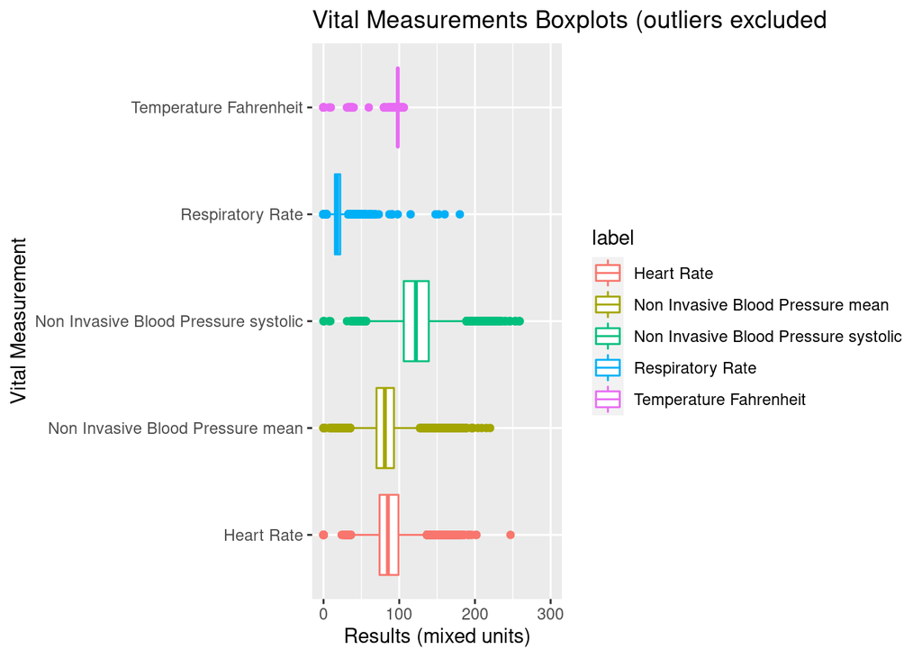

```r
chart_box <- chartevents_tble %>%
  select(2:6) %>%
  pivot_longer(1:5, names_to = "label", values_to = "values")
sixthree <- ggplot(chart_box, aes(x = label, y = values, color = label)) +
  geom_boxplot()
sixthree + coord_flip() + xlab("Vital Measurement") +
  ylab("Results (mixed units)") +
  ggtitle("Vital Measurements Boxplots (outliers excluded") +
  ylim(0, 300)
```

## Q7. Putting things together

Let us create a tibble `mimic_icu_cohort` for all ICU stays, where rows are

- first ICU stay of each unique adult (age at admission > 18)

and columns contain at least following variables

- all variables in `icustays.csv.gz`
- all variables in `admission.csv.gz`
- all variables in `patients.csv.gz`
- first lab measurements during ICU stay
- first vital measurements during ICU stay
- an indicator variable `thirty_day_mort` whether the patient died within 30 days of hospital admission (30 day mortality)

**Solution**

```r
mimic_icu_cohort <- icustays_tble %>%
  left_join(patients_tble, by = "subject_id") %>%
  left_join(admissions_tble, by = c("hadm_id", "subject_id")) %>%
  left_join(labevents_tble, by = "subject_id") %>%
  left_join(chartevents_tble, by = "subject_id") %>%
  mutate(age_hadm = anchor_age + year(admittime) - anchor_year) %>%
  filter(age_hadm > 18) %>%
  mutate(thirty_day_mort = "No")
mimic_icu_cohort$thirty_day_mort <- ifelse(is.na(mimic_icu_cohort$deathtime),
         "No", ifelse(lubridate::year(mimic_icu_cohort$deathtime) -
         lubridate::year(mimic_icu_cohort$admittime) <= 30, "Yes", "No"))

mimic_icu_cohort
```

```
## # A tibble: 53,065 × 43
##    subject_id  hadm_id  stay_id first_careunit last_careunit intime
##         <dbl>    <dbl>    <dbl> <chr>          <chr>         <dttm>
##  1   18106347 24305596 30588857 Cardiac Vascu… Cardiac Vasc… 2110-01-11 10:16:06
##  2   17195991 23542772 38319097 Surgical Inte… Surgical Int… 2110-01-12 00:54:00
##  3   16284044 23864737 36817845 Cardiac Vascu… Cardiac Vasc… 2110-01-13 09:09:40
##  4   18122666 23883987 39753527 Medical/Surgi… Medical/Surg… 2110-01-14 07:22:00
##  5   18780420 28977824 32140208 Neuro Surgica… Neuro Surgic… 2110-01-17 00:28:00
##  6   15092543 28768907 38339174 Neuro Interme… Neuro Interm… 2110-01-17 22:49:13
##  7   13201095 28453791 39953418 Coronary Care… Coronary Car… 2110-01-18 14:46:27
##  8   12770182 20446666 34901199 Medical Inten… Medical Inte… 2110-01-18 17:47:47
##  9   12224263 23294937 37546608 Trauma SICU (… Trauma SICU … 2110-01-20 14:01:00
## 10   19564586 22461053 37310703 Coronary Care… Coronary Car… 2110-01-20 21:06:30
## # … with 53,055 more rows, and 37 more variables: outtime <dttm>, los <dbl>,
## #   gender <chr>, anchor_age <dbl>, anchor_year <dbl>, anchor_year_group <chr>,
## #   dod <date>, admittime <dttm>, dischtime <dttm>, deathtime <dttm>,
## #   admission_type <chr>, admission_location <chr>, discharge_location <chr>,
## #   insurance <chr>, language <chr>, marital_status <chr>, ethnicity <chr>,
## #   edregtime <dttm>, edouttime <dttm>, hospital_expire_flag <dbl>,
## #   Bicarbonate <dbl>, Calcium, Total <dbl>, Chloride <dbl>, …
```

## Q8. Exploratory data analysis (EDA)

Summarize following information using appropriate numerics or graphs.

- `thirty_day_mort` vs demographic variables (ethnicity, language, insurance, marital_status, gender, age at hospital admission)

**Solution**

Ethnicity

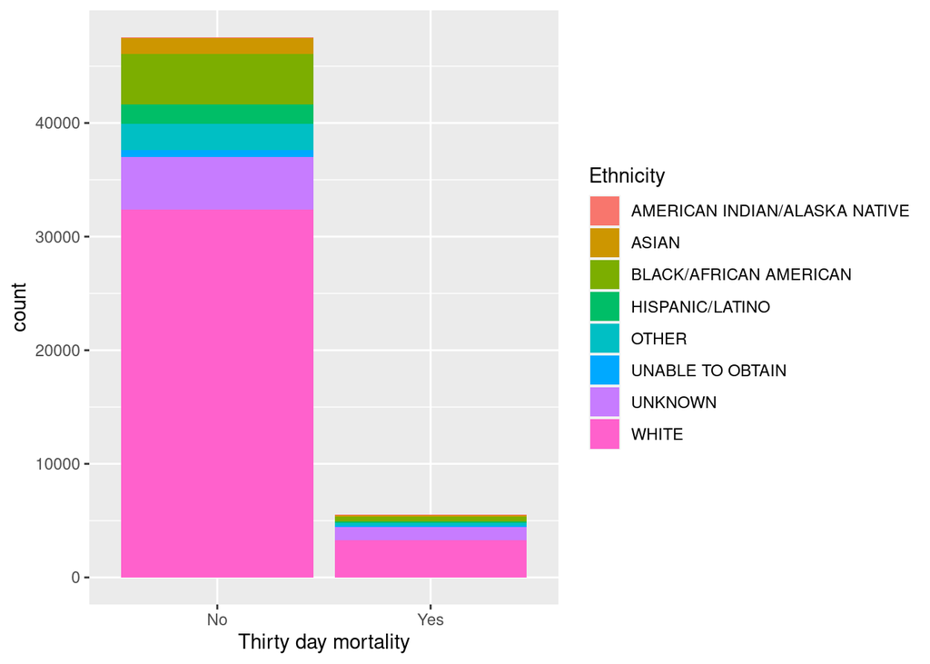

```r
mort_eth <- mimic_icu_cohort %>%
  select(ethnicity, thirty_day_mort) %>%
  ggplot(aes(thirty_day_mort))
mort_eth + geom_bar(aes(fill = ethnicity)) +
  scale_fill_discrete(name="Ethnicity") + xlab("Thirty day mortality")
```

Language

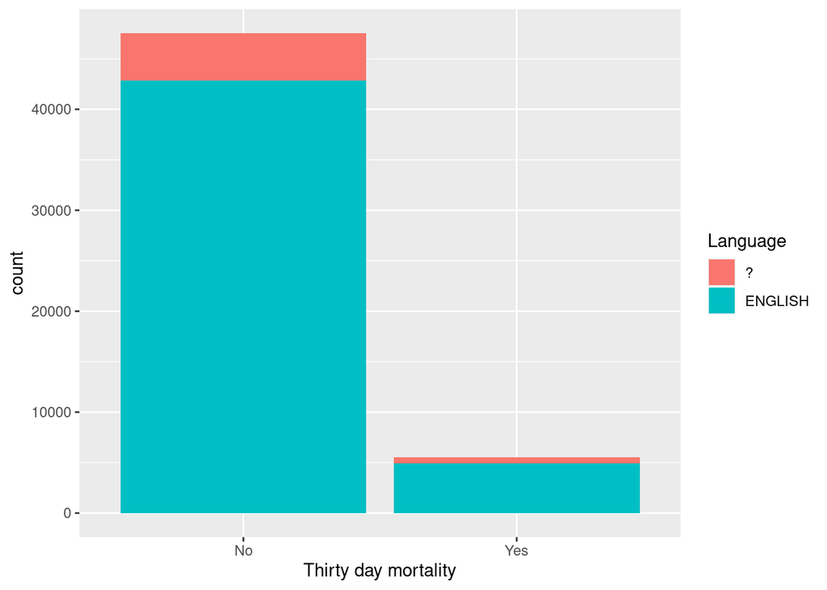

```r
mort_lang <- mimic_icu_cohort %>%
  select(language, thirty_day_mort) %>%
  ggplot(aes(thirty_day_mort))
mort_lang + geom_bar(aes(fill = language)) +
  scale_fill_discrete(name="Language") + xlab("Thirty day mortality")
```

Insurance

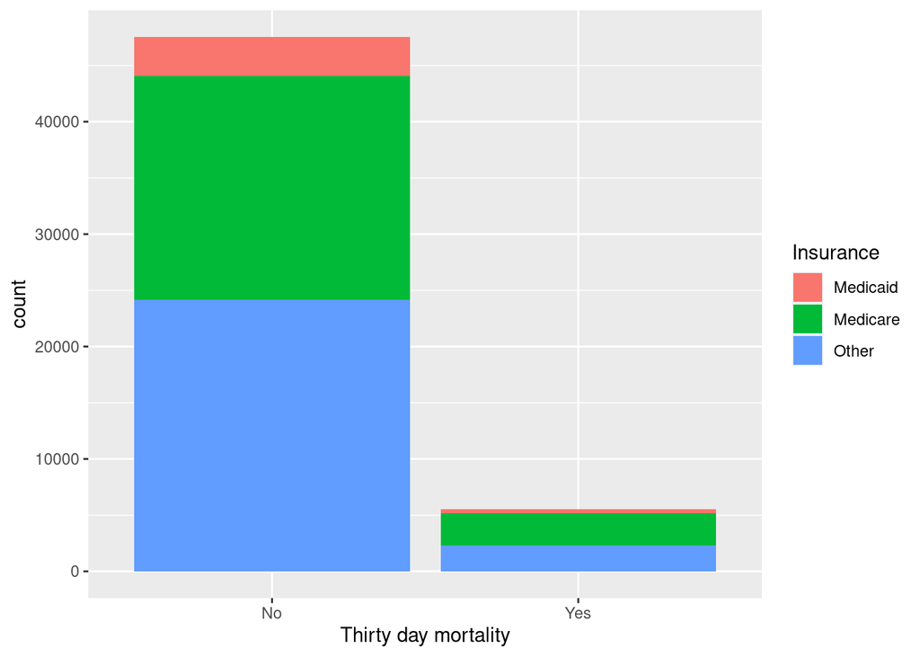

```r
mort_ins <- mimic_icu_cohort %>%
  select(insurance, thirty_day_mort) %>%
  ggplot(aes(thirty_day_mort))
mort_ins + geom_bar(aes(fill = insurance)) +
  scale_fill_discrete(name="Insurance") + xlab("Thirty day mortality")
```

Marital status

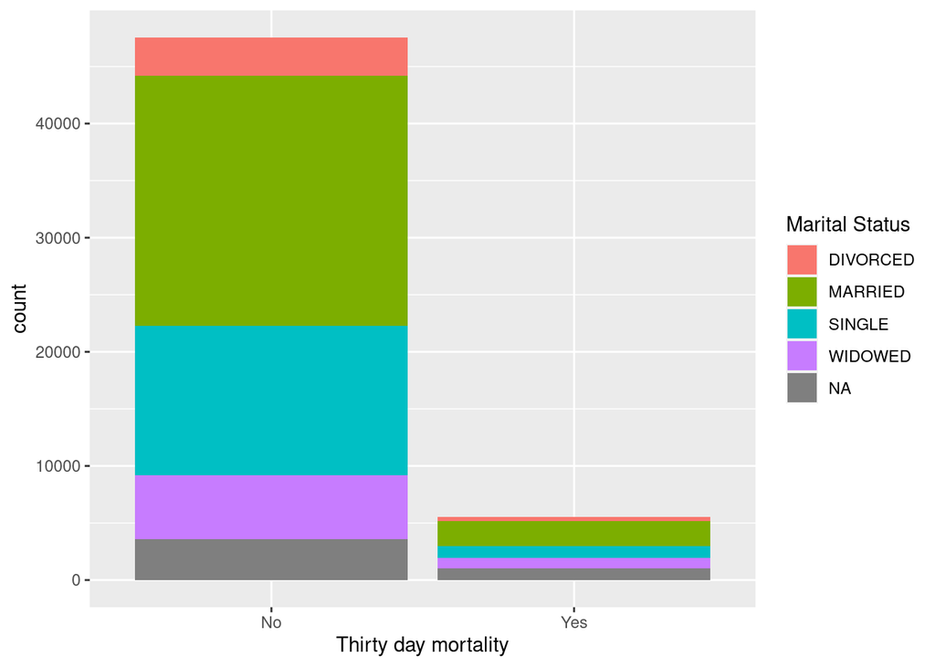

```r
mort_mar <- mimic_icu_cohort %>%
  select(marital_status, thirty_day_mort) %>%
  ggplot(aes(thirty_day_mort))
mort_mar + geom_bar(aes(fill = marital_status)) +
  scale_fill_discrete(name="Marital Status") + xlab("Thirty day mortality")
```

- `thirty_day_mort` vs first lab measurements

**Solution**

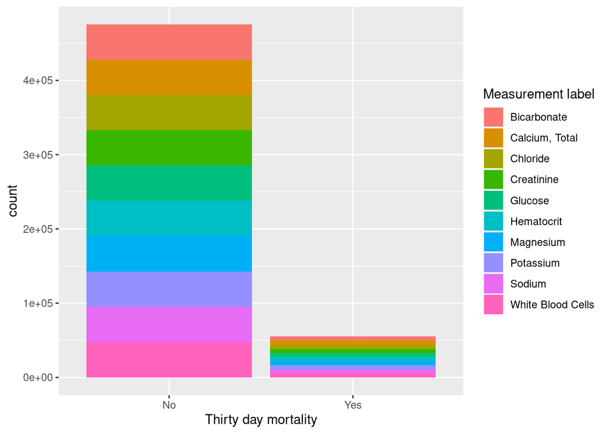

```r
mort_lab <- mimic_icu_cohort %>%
  select(27:36, thirty_day_mort) %>%
  pivot_longer(1:10, names_to = "measurement", values_to = "value") %>%
  ggplot(aes(thirty_day_mort))
mort_lab + geom_bar(aes(fill = measurement)) +
  scale_fill_discrete(name="Measurement label") + xlab("Thirty day mortality")
```

Gender

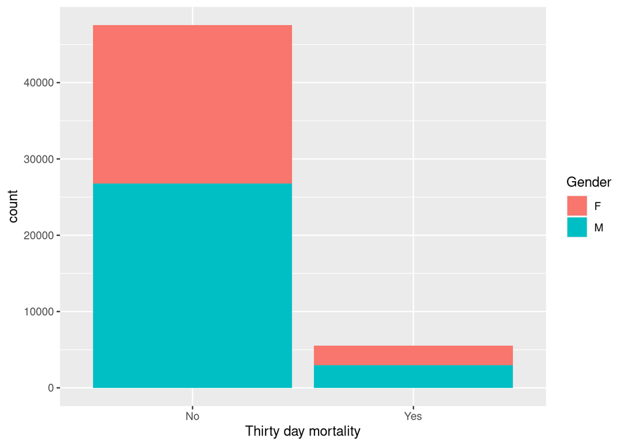

```r
mort_gen <- mimic_icu_cohort %>%
  select(gender, thirty_day_mort) %>%
  ggplot(aes(thirty_day_mort))
mort_gen + geom_bar(aes(fill = gender)) +
  scale_fill_discrete(name="Gender") + xlab("Thirty day mortality")
```

Age at hospital admission

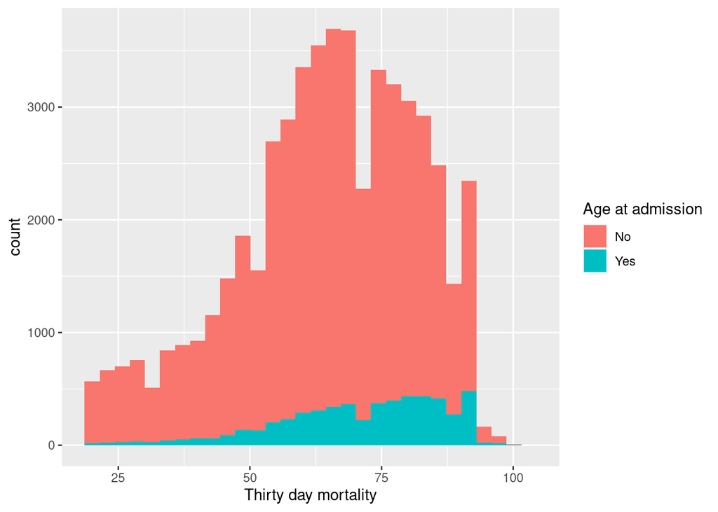

```r
mort_age <- mimic_icu_cohort %>%
  select(age_hadm, thirty_day_mort) %>%
  ggplot(aes(age_hadm))
mort_age + geom_histogram(aes(fill = thirty_day_mort)) +
  scale_fill_discrete(name="Age at admission") + xlab("Thirty day mortality")
```

- `thirty_day_mort` vs first vital measurements

**Solution**

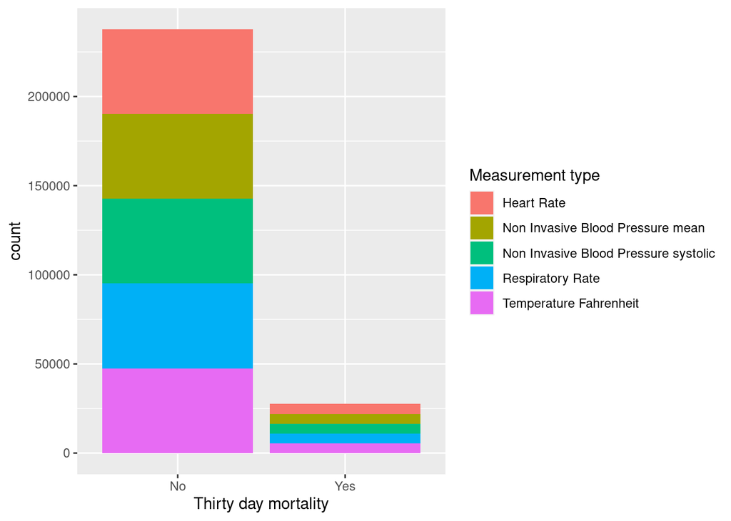

```r
mort_vital <- mimic_icu_cohort %>%
  select(37:41, thirty_day_mort) %>%
  pivot_longer(1:5, names_to = "measurement", values_to = "value") %>%
  ggplot(aes(thirty_day_mort))
mort_vital + geom_bar(aes(fill = measurement)) + xlab("Thirty day mortality") +
  scale_fill_discrete(name="Measurement type")
```

- `thirty_day_mort` vs first ICU unit

**Solution**

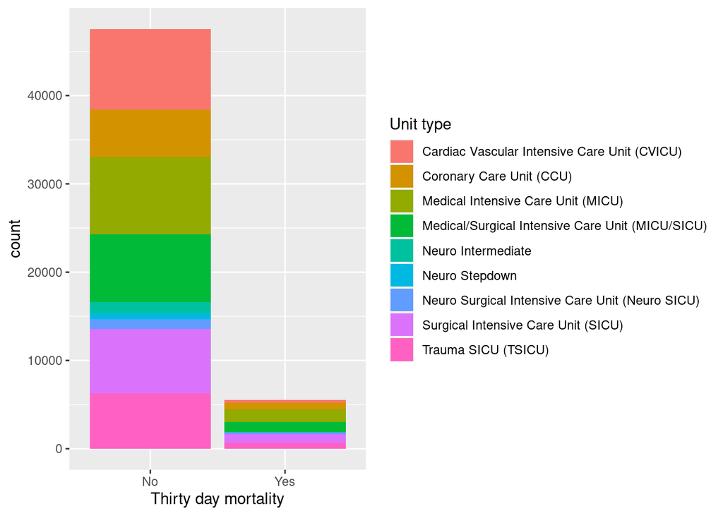

```r
mort_unit <- mimic_icu_cohort %>%
  select(first_careunit, thirty_day_mort) %>%
  ggplot(aes(thirty_day_mort))
mort_unit + geom_bar(aes(fill = first_careunit)) +
  xlab("Thirty day mortality") + scale_fill_discrete(name="Unit type")
```